# Análisis de Conglomerados

Sergio Martí

2022-11-28

# Análisi de Conglomerados

Después de realizar una extracción o selección de variables, se puede realizar un análisis de conglomerados. O en otras palabras, agrupar los individuos por su parecido, intentando formar grupos homogeneos.

## Importar las librerias necesarias

Son necesarias las librerías: tidyverse, ggdendro

```r
# Instalar, si no lo está, tidyverse
if (!require(tidyverse, quietly = TRUE)) {
  install.packages(tidyverse)
}
```

```r
# Instalar, si no lo está, ggdendro
if (!require("ggdendro", quietly = TRUE)) {
  install.packages("ggdendro")
}
# Instalar, si no está instalado, weitexl: paquete para guardar como excel dataframes
if (!require("writexl", quietly = TRUE)) {
  install.packages("writexl")
}
```

## Leer los datos

Cargamos los datos resultantes del PCA.

```r
# Leer el objeto rds con los datos del pca que tiene las CPs 1 - 4
pcaData <- readRDS("../PCA/pcaData2.rds")
```

## Matriz de distancias/similitud

La matriz de distancias resume la similitud de los individuos entre si. Se puede calcular de distintas formas, mediante la distancia euclidea, manhattan, coeficiente de correlación de pearson… etc. Se han calculado la matriz mediante la función de distancia euclidea (el método más común en estos casos). Se han utilizado las 4 primeras componentes principales (retienen el 57% de la información original).

```r
# Matriz de distancias
mDist <- as.matrix(dist(pcaData[,c(1,2,3,4)], method = "euclidean"))
```

Representación gráfica de la matriz de distancias.

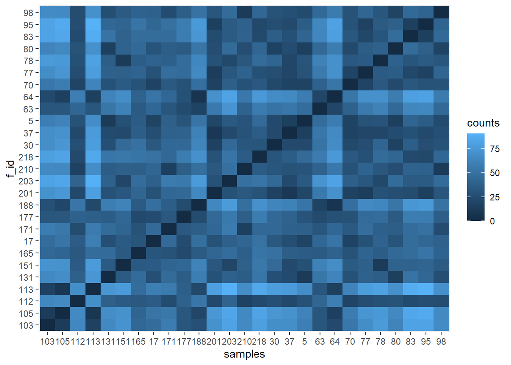

```r
library(tidyverse)
library(ggplot2)

# La ubicación donde guardar el gráfico
dir.create(file.path(getwd(), "img"), showWarnings = FALSE)

# Reordeno la matriz para generar un df
dfDist <- mDist %>%
  as.data.frame() %>%
  rownames_to_column("f_id") %>%
  pivot_longer(-c(f_id), names_to = "samples", values_to = "counts")

# Gráfica con ggplot2
gDist <- ggplot(dfDist, aes(x = samples, y = f_id, fill = counts)) +
  geom_tile(); gDist
```

## Herarquical clusttering

Con la matriz de distancias se puede realizar un análisis de conglomerados jerárquico.

```r
# Clusttering herarquico
# NOTA: por algún motivo la función hclust da error cuando se le pasa el objeto mDist
hc <- hclust(dist(pcaData[,c(1,2)], method = "euclidean"), method = "complete"); hc
```

```
##
## Call:
## hclust(d = dist(pcaData[, c(1, 2)], method = "euclidean"), method = "complete")
##
## Cluster method   : complete
## Distance         : euclidean
## Number of objects: 27
```

```r
# Existe una función llamada cutree que permite cortar según el número de grupos que se quieren separar
cluster <- cutree(hc, 5)

pcaData$Cluster <- as.factor(cluster)
```

El gráfico utilizado para representar el clusttering jerárquico es un dendograma.

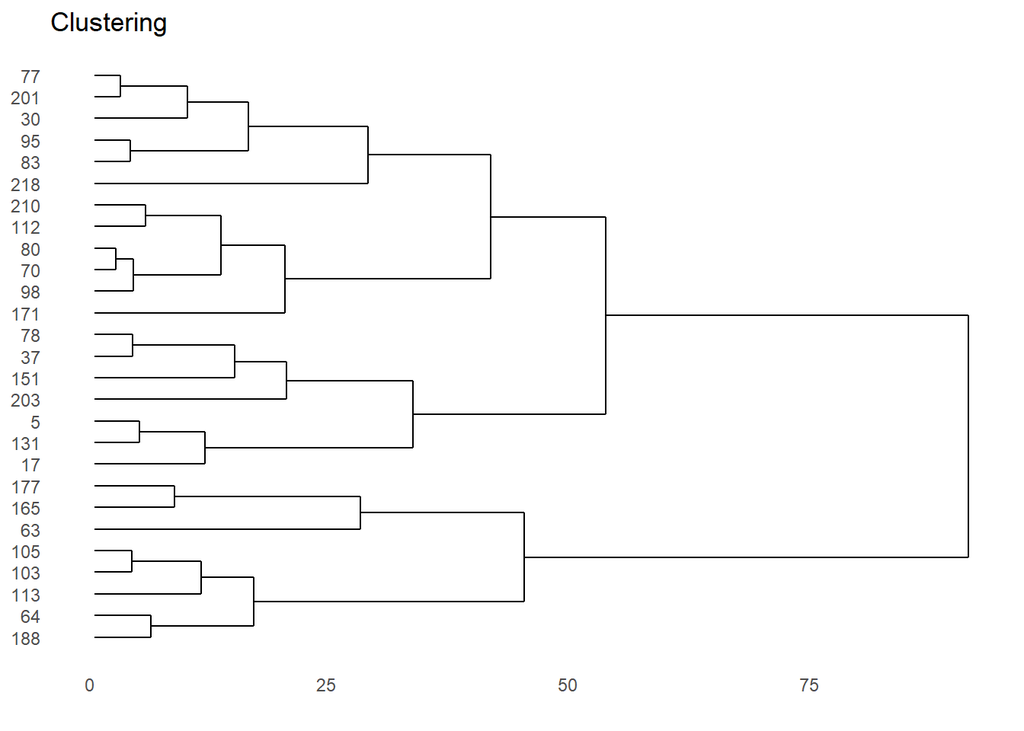

```r
library(ggplot2)
library(ggrepel)
# Dendograma
hcplot <- ggdendro::ggdendrogram(hc, rotate = TRUE) +
  ggtitle("Clustering"); hcplot
```

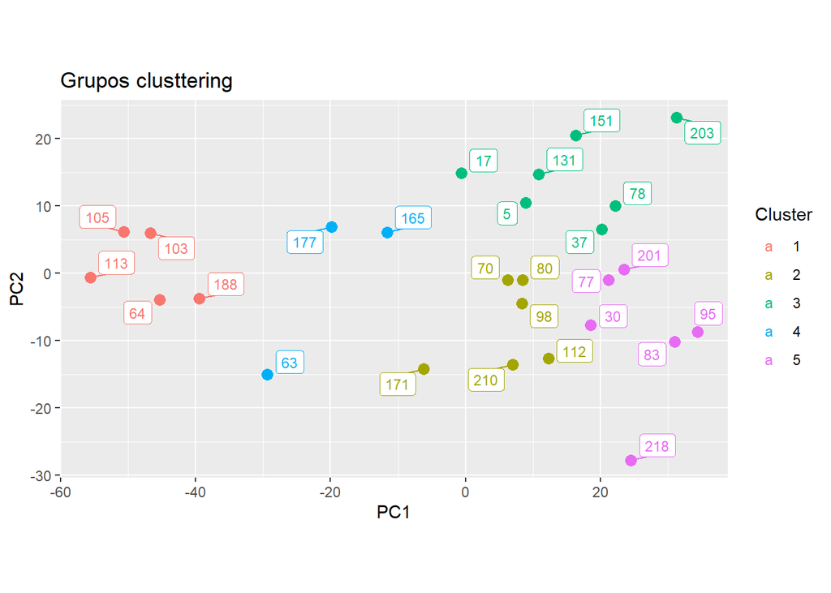

```r
# Guardamos el dendograma
ggsave("./img/hcplot_01.png", plot = hcplot)
# Dispersión según clusttering
gClust <- ggplot(pcaData, aes(PC1, PC2, color = Cluster, label = row.names(pcaData))) +
  geom_point(size=3) +
  geom_label_repel(size = 3) +
  xlab("PC1") +
  ylab("PC2") +
  ggtitle("Grupos clusttering") +
  coord_fixed(); gClust
```

```r
# Guardamos el gráfico de dispersión, con los grupos del clusttering
ggsave("./img/PCA_clust.png", plot = gClust)
```

## Heatmap

Un mapa de calor es la representación gráfica de la matriz de distancias y el clusttering jerárquico.

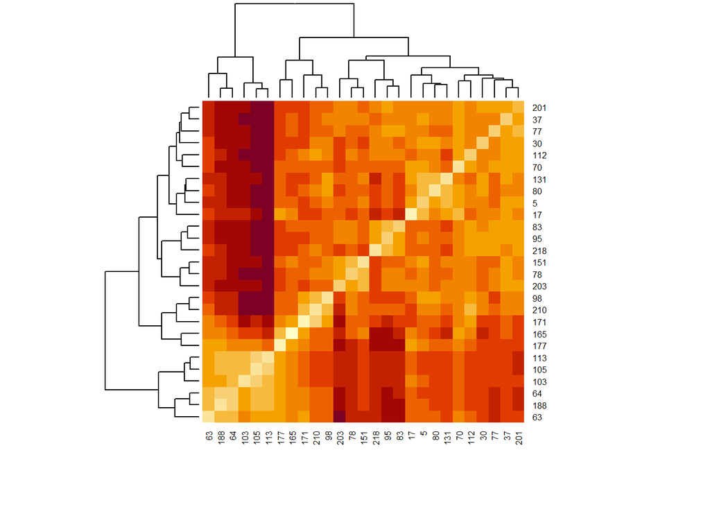

```r
# @see: https://stackoverflow.com/questions/3081066/what-techniques-exists-in-r-to-visualize-a-distance-matrix

heatmap(mDist, cexRow = 0.6, cexCol = 0.6)
```

```r
# ---

png('./img/heatmap.png')

svg('./img/heatmap.svg')

heatmap(mDist, cexRow = 0.6, cexCol = 0.6)

dev.off()
```

## Guardar el clusttering

Se puede guardar como un RDS y como un excel.

```r
# --- Guardar como Excel --- #
library("writexl")

# Guardamos las componentes principales 1
write_xlsx(pcaData, "./pcaDataClust.xlsx")

# --- Guardar como RDS --- #
saveRDS(pcaData, "./pcaDataClust.rds")
```